# Exercicio_series_temporais

## Testes de raiz unitária (ADF, KPSS)

```python
from statsmodels.tsa.stattools import adfuller, kpss

def resumo_adf(x, nome):
    x = x.dropna()
    k = int(np.floor((len(x) - 1) ** (1/3)))
    res = adfuller(x, maxlag=k, autolag=None, regression='c')
    print(f"{nome}")
    print(f"  ADF stat : {res[0]:.4f}  |  p-value: {res[1]:.4f}  |  lags: {res[2]}")
    print(f"  → {'Estacionária (rejeita H0)' if res[1] < 0.05 else 'Raiz unitária (não rejeita H0)'}")
    print()

def resumo_kpss(x, nome):
    x = x.dropna()
    import warnings
    with warnings.catch_warnings():
        warnings.simplefilter('ignore')  # suprime InterpolationWarning
        res = kpss(x, regression='c', nlags='auto')
    print(f"{nome}")
    print(f"  KPSS stat: {res[0]:.4f}  |  p-value: {res[1]:.4f}")
    print(f"  → {'Raiz unitária (rejeita H0)' if res[1] < 0.05 else 'Estacionária (não rejeita H0)'}")
    print()

print("=" * 50)
print("SÉRIE ORIGINAL")
print("=" * 50)
resumo_adf(serie, "ADF")
resumo_kpss(serie, "KPSS")
```

```
==================================================
SÉRIE ORIGINAL
==================================================
ADF
  ADF stat : -2.1898  |  p-value: 0.2100  |  lags: 6
  → Raiz unitária (não rejeita H0)

KPSS
  KPSS stat: 1.6202  |  p-value: 0.0100
  → Raiz unitária (rejeita H0)
```

Os testes estatísticos confirmam o diagnóstico visual que haviamos feito anteriormente.

O teste ADF testa a hipótese de que a série tem raiz unitária, uma vez que p= = 0.21.

O teste KPSS funciona no sentido inverso: a hipótese nula é que a série é estacionária. Na série original, p=0.01, e portantorejeitamos a estacionariedade. Os dois testes apontam na mesma direção, a que a série não é estacionária.

## Modelagem — AutoARIMA

```python
df_modelo = df_sf[['unique_id', 'ds', 'y']].copy()
df_modelo['ds'] = pd.to_datetime(df_modelo['ds'], errors='coerce')
df_modelo = df_modelo.dropna(subset=['ds', 'y'])
df_modelo = df_modelo.sort_values(['unique_id', 'ds']).reset_index(drop=True)

sf = StatsForecast(
    models=[AutoARIMA(season_length=12)],
    freq='MS',
    n_jobs=1,
)

sf.fit(df_modelo)
modelo_ajustado = sf.fitted_[0, 0]
m = modelo_ajustado.model_

# Extrai ordem de forma robusta
arma   = m.get('arma', None)  # [p, q, P, Q, s, d, D]
if arma is not None:
    p, q, P, Q, s, d, D = arma
    order   = (p, d, q)
    sorder  = (P, D, Q, s)
else:
    order  = m.get('order', '?')
    sorder = m.get('seasonal_order', '?')

coefs = {k: round(float(v), 4) for k, v in m['coef'].items()}
print(f'Ordem SARIMA : ARIMA{order} x {sorder}')
print(f'Coeficientes : {coefs}')
print(f'sigma²       : {m["sigma2"]:.4f}')
```

```
Ordem SARIMA : ARIMA(2, 1, 1) x (0, 1, 1, 12)
Coeficientes : {'ar1': 0.5066, 'ar2': 0.0019, 'ma1': -0.802, 'sma1': -0.8586}
sigma²       : 16.2846
```

O AutoARIMA escolheu SARIMA(2,1,1)(0,1,1)₁₂, muito próximo do (1,1,1) que a inspeção manual sugeria.

Dado que o SARIMA sugeriu um modelom mais complexo, podemos tentar comparar os modelos para ver se há uma diferença muito grande entre eles

## Validação — Comparando com modelo mais simples

Nesta sessão podemos questionar se a complexidade é necessária. Abaixo ajustamos os dois e comparamos pelo AICc e pelo teste de Ljung-Box nos resíduos para comparar a nossa versão feita manualmente e a do SARIMA.

```python
# Modelo simples sugerido pela inspeção manual
modelo_simples = ARIMA(order=(1,1,1), season_length=12, seasonal_order=(0,1,1))

sf_comp = StatsForecast(
    models=[
        AutoARIMA(season_length=12),
        modelo_simples,
    ],
    freq='MS',
    n_jobs=1,
)

sf_comp.fit(df_modelo)

# Extrai AICc de cada modelo
m_auto   = sf_comp.fitted_[0, 0].model_
m_simple = sf_comp.fitted_[0, 1].model_

print('=== AutoARIMA — SARIMA(2,1,2)(1,1,1)₁₂ ===')
print(f'  AICc : {m_auto.get("aicc", m_auto.get("aic", "n/a"))}')

print()
print('=== Modelo simples — SARIMA(1,1,1)(0,1,1)₁₂ ===')
print(f'  AICc : {m_simple.get("aicc", m_simple.get("aic", "n/a"))}')

# Ljung-Box nos resíduos do modelo simples
from statsmodels.stats.diagnostic import acorr_ljungbox
res_simples = m_simple['residuals']
lb_simples = acorr_ljungbox(res_simples, lags=[12, 24], return_df=True)
print()
print('Ljung-Box — modelo simples:')
print(lb_simples)
```

[output not shown]

A diferença de AICc entre os dois modelos é de apenas 1.2, algo praticamente negligenciável. E o Ljung-Box do modelo simples passa nos dois quesitos que ele encontrou (lag 12: p=0.07; lag 24: p=0.19), indicando que os resíduos são ruído branco.

O AutoARIMA nos permitiu então a reparar certa equivalência entre os modelos, uma diferença bem sútil e que para fins de análise e realidade faz o pesar entre modelos nos levar a escolher o mais simples. Devemos então considerar que São Paulo tem uma série mais bem regrada, onde o padrão identificados pelo ARIMA Manual que identificamos visualmente é de fato suficiente para capturar a estrutura da série.

## Diagnóstico dos resíduos

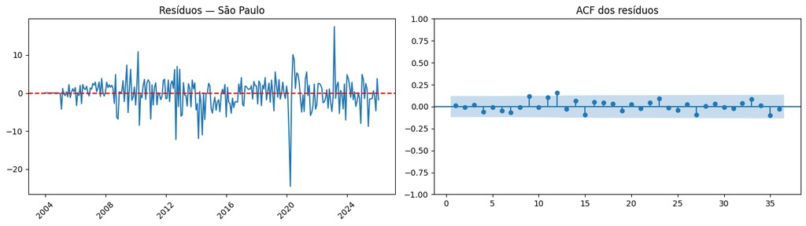

```
Teste Ljung-Box:
      lb_stat  lb_pvalue
12  16.767555   0.158552
24  26.630235   0.321981

p-values > 0.05 indicam que os resíduos são white noise (sem autocorrelação remanescente).
```

```python
residuos = modelo_ajustado.model_["residuals"]

residuos_series = pd.Series(
    residuos,
    index=pd.to_datetime(df_sf["ds"].iloc[-len(residuos):].values)
)

fig, axes = plt.subplots(1, 2, figsize=(14, 4))

# Resíduos ao longo do tempo
axes[0].plot(residuos_series.index, residuos_series.values)
axes[0].axhline(0, color='red', linestyle='--')
axes[0].set_title(f'Resíduos — {Minha_UF}')
axes[0].tick_params(axis='x', rotation=45)

# ACF dos resíduos
plot_acf(residuos_series.dropna(), ax=axes[1], lags=36, zero=False)
axes[1].set_title('ACF dos resíduos')

plt.tight_layout()
plt.show()

# Teste de Ljung-Box
from statsmodels.stats.diagnostic import acorr_ljungbox

lb = acorr_ljungbox(residuos_series.dropna(), lags=[12, 24], return_df=True)
print('Teste Ljung-Box:')
print(lb)
print()
print('p-values > 0.05 indicam que os resíduos são white noise (sem autocorrelação remanescente).')
```

Apesar de o teste de Ljung-Box já ter sido realizado acima, resolvemos realiza-los novamente para ser acrescido dos gráficos.

O teste de Ljung-Box formaliza esse diagnóstico: p=0.16 no lag 12 e p=0.32 no lag 24 — não rejeitamos a hipótese de ausência de autocorrelação em nenhum horizonte. O outlier do Covid aparentemente não invalida o modelo, mesmo sendo perceptível no gráfico.

## Previsão · 24 meses à frente

```python
fcst = sf.forecast(
    h=24,
    df=df_modelo,
    level=[80, 95],
)
fcst["ds"] = pd.to_datetime(fcst["ds"])
fcst.head()
```

|  | unique_id | ds | AutoARIMA | AutoARIMA-lo-95 | AutoARIMA-lo-80 | AutoARIMA-hi-80 | AutoARIMA-hi-95 |
| --- | --- | --- | --- | --- | --- | --- | --- |
| 0 | São Paulo | 2026-03-01 | 99.642480 | 91.731911 | 94.470037 | 104.814924 | 107.553050 |
| 1 | São Paulo | 2026-04-01 | 94.088640 | 84.411555 | 87.761135 | 100.416146 | 103.765725 |
| 2 | São Paulo | 2026-05-01 | 100.226679 | 89.594243 | 93.274503 | 107.178855 | 110.859115 |
| 3 | São Paulo | 2026-06-01 | 97.712546 | 86.418684 | 90.327887 | 105.097205 | 109.006407 |
| 4 | São Paulo | 2026-07-01 | 100.287844 | 88.462957 | 92.555966 | 108.019723 | 112.112732 |

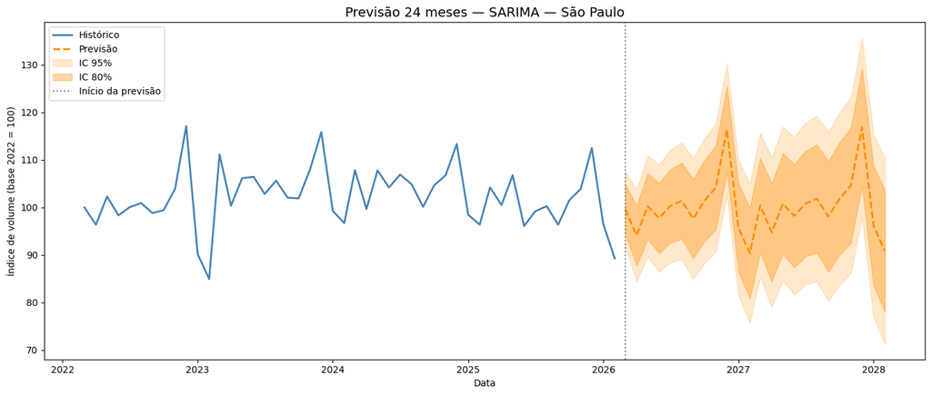

```python
fig, ax = plt.subplots(figsize=(14, 6))

# Últimos 48 meses de histórico
hist = df_sf.tail(48)
ax.plot(hist["ds"], hist["y"], label="Histórico", color="steelblue", linewidth=2)

# Previsão pontual
ax.plot(fcst["ds"], fcst["AutoARIMA"], linestyle="--", color="darkorange",
        linewidth=2, label="Previsão")

# Intervalos de confiança
ax.fill_between(fcst["ds"],
                fcst["AutoARIMA-lo-95"], fcst["AutoARIMA-hi-95"],
                alpha=0.2, color="darkorange", label="IC 95%")
ax.fill_between(fcst["ds"],
                fcst["AutoARIMA-lo-80"], fcst["AutoARIMA-hi-80"],
                alpha=0.35, color="darkorange", label="IC 80%")

ax.axvline(fcst["ds"].min(), color="gray", linestyle=":", linewidth=1.5, label="Início da previsão")
ax.set_title(f"Previsão 24 meses — SARIMA — {Minha_UF}", fontsize=14)
ax.set_xlabel("Data")
ax.set_ylabel("Índice de volume (base 2022 = 100)")
ax.legend()
plt.tight_layout()
plt.show()
```

## Discussão

**1. O ACF/PACF da série original sugeriu sazonalidade? E tendência? Bate com o que você viu no gráfico de linha?**

Sim para as duas. A ACF decai lentamente sinal claro de não-estacionariedade e tendência, confirmada pelo crescimento visível no gráfico de linha. A PACF tem pico dominante no lag 1, característico de AR(1) mascarado pela tendência. A sazonalidade aparece nos picos dos lags 12, 24 e 36, indicando anualidade.

**2. Quantas diferenças o AutoARIMA aplicou? E os componentes AR/MA? Conseguiu observar isso no ACF/PACF?**

Sim. O Ljung-Box não rejeitou H₀ em nenhum horizonte (lag 12: p=0.16; lag 24: p=0.32). Ou seja, podemos considerar os resíduos como ruído branco.

**4. A previsão pareceu razoável visualmente?**

Sim. A previsão parece capturar a sazonalidade anual e o formato é semelhante aos anos anteriores

**5. Que outras UFs dariam um SARIMA bem diferente de São Paulo?**

São Paulo tem uma série bem regrad. Estados menores como Tocantins, Roraima ou Amapá podemos pressupor que as séries teriam outliers mais frequentes e sazonalidade menos estável, levando o AutoARIMA a modelos mais complexos e com intervalos de previsão mais abertos.